# Week2-Assignment

## Step-1 Load Dataset into SQL Database

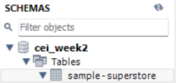

## Step-2 Explore Table(schema,sample data)

### 2. describe `sample - superstore`;

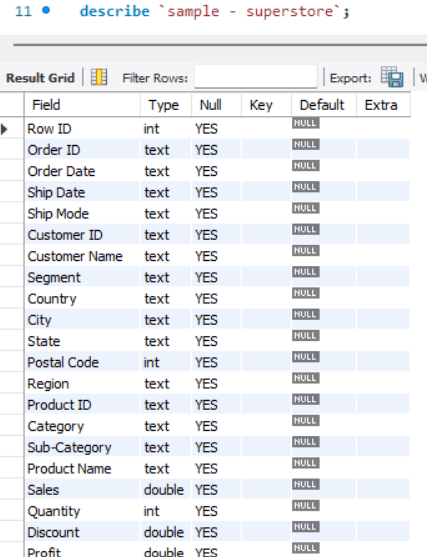

#### Insight:

#### The schema provides information about column names and data types,which is essential for further analysis

### 2. select * from `sample - superstore` limit 10;

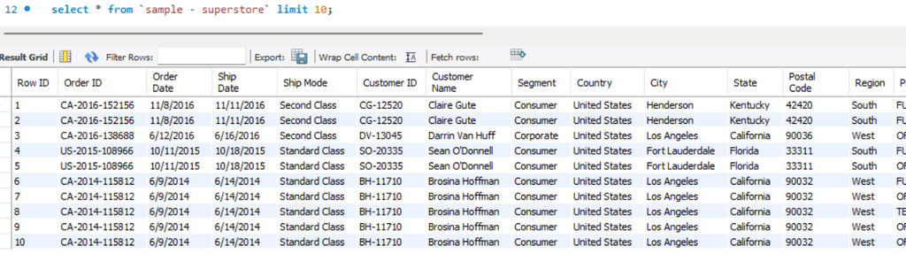

#### Insight:

#### The query displays sample records from the dataset and helps understand the structure and available attributes.

## Step-3 Apply where filters

### 1. Region

### select `Order ID`,Sales,Category,Region from `sample - superstore` where Region='West';

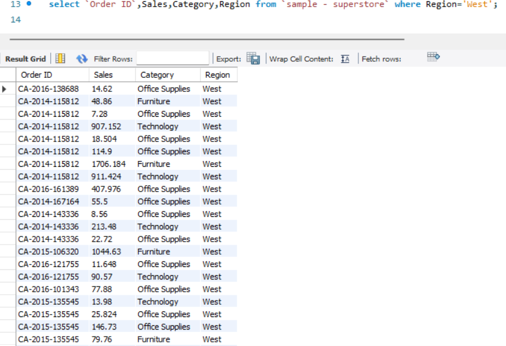

#### Insight:

#### The query retrieves sales records belonging only to the West region for regional analysis.

### 2. Category

### select `Order ID`,Sales,Category from `sample - superstore` where Category='Technology';

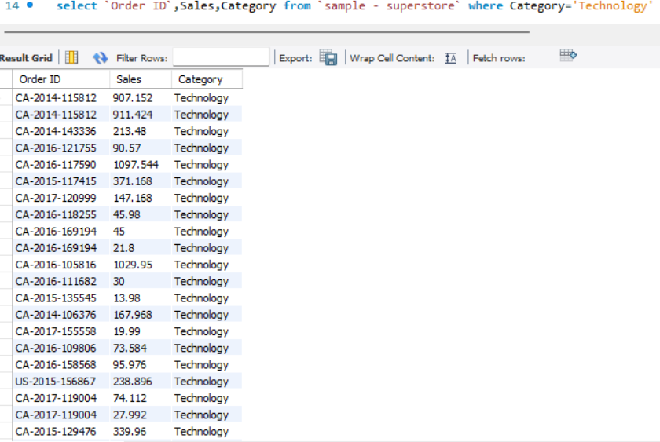

#### Insight:

#### The query focuses on products in the Technology category to analyze category-specific sales.

### 3. Date

### select `Order ID`,`Order Date`,Region,Sales from `sample - superstore` where str_to_date(`Order Date`,'%m/%d/%Y') between '2016-01-01' and '2016-12-31';

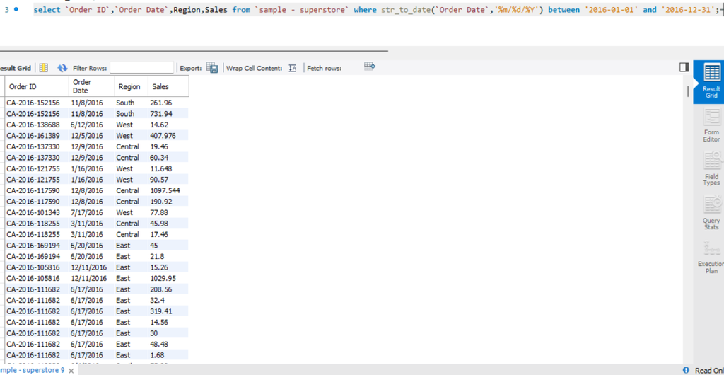

#### Insight:

#### The query filters records within a specified date range to analyze time-based sales activity.

### 4. Sales

### select `Order ID`,Sales from `sample - superstore` where Sales>500;

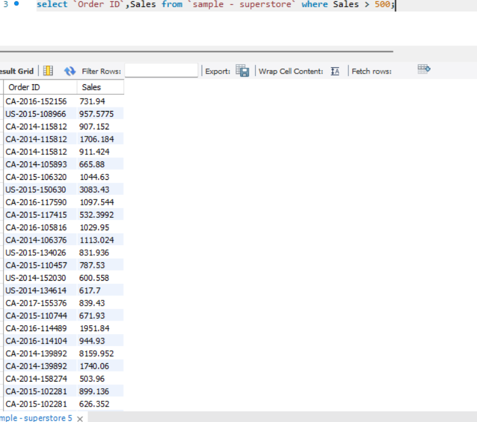

#### Insight:

#### The query identifies high-value transactions with sales greater than 500.

## Step-4 GROUP BY for aggregations

### 1. Sales

### select Category,SUM(Sales) from `sample - superstore` group by Category;

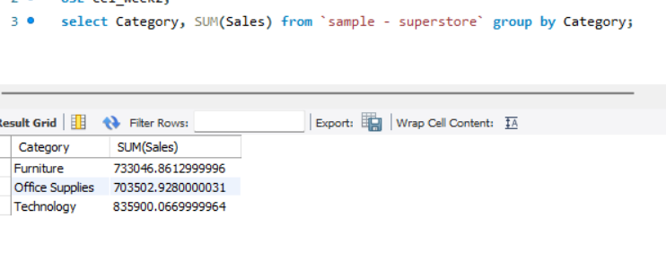

#### Insight:

#### The query summarizes total sales for each category, enabling category-wise performance comparison.

### 2.Averages

### select Category,AVG(sales) from `sample - superstore` group by Category;

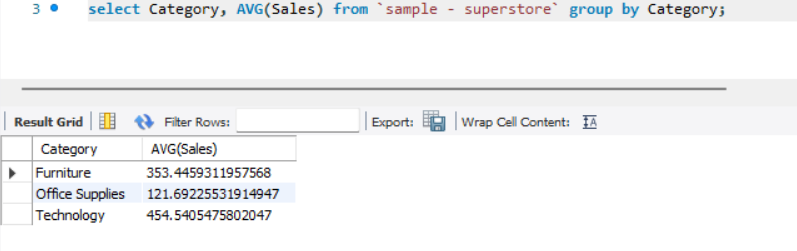

#### Insight:

#### The query calculates average sales per category to evaluate typical transaction values

### 3. Quantity

### select Category,AVG(Quantity) from `sample - superstore` group by Category;

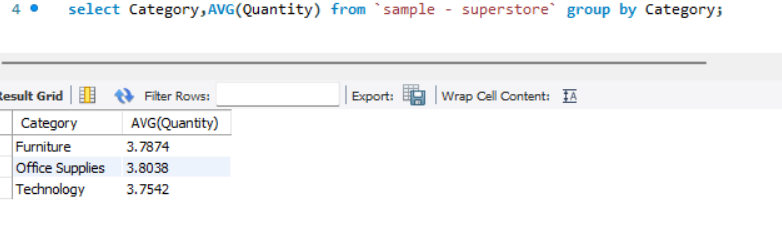

## Step-5 Sort and limit results

### select Category,SUM(Sales) as Total_Sales from `sample - superstore` group by Category order by Total_Sales desc limit 3;

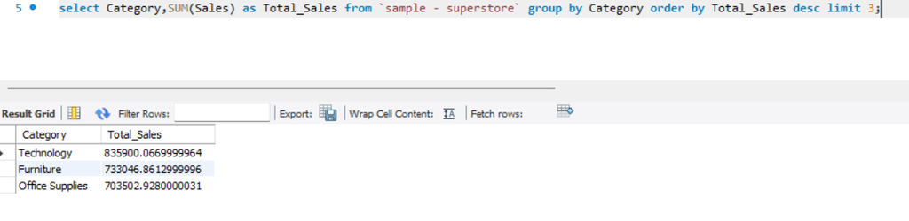

#### Insight:

#### The query ranks categories based on total sales contribution.

### select `Product Name`,SUM(Sales) as Total_Sales from `sample - superstore` group by `Product Name` order by Total_Sales desc limit 5;

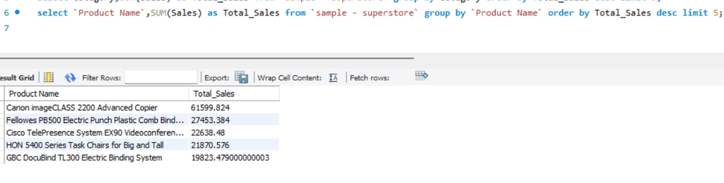

#### Insight:

#### The query identifies the highest revenue-generating products in the dataset.

## Step-6 Solve use cases

### 1. Monthly Trend

### select year(str_to_date(`Order Date`,'%m/%d/%Y')) as year_,month(str_to_date(`Order Date`,'%m/%d/%Y')) as month_, sum(sales) as total_sales from `sample - superstore` group by year_,month_ order by year_,month_;

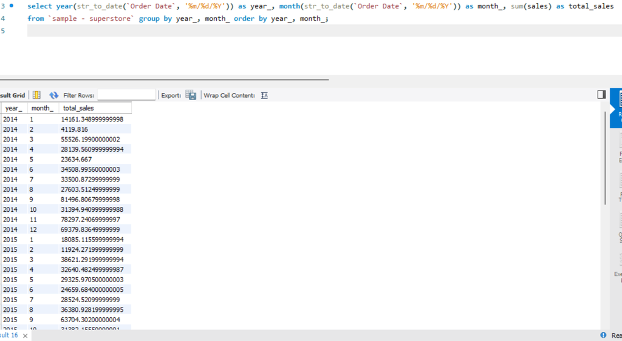

#### Insight:

#### The query analyzes sales trends over time and helps identify monthly variations in revenue.

### 2. Top 10 customers

### select `Customer Name`,sum(sales) as total_sales from `sample - superstore` group by `Customer Name` order by total_sales desc limit 10;

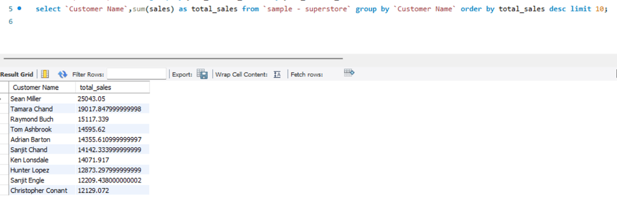

#### Insight:

#### The query identifies customers who contributed the most revenue.

### 3. Duplicate orders

### select `Order ID`,count(*) as duplicate_count from `sample - superstore` group by `Order ID` having count(*)>1;

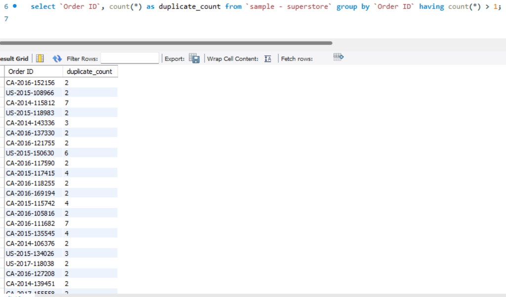

#### Insight:

#### The query checks for repeated Order IDs and helps assess data consistency.

## Step-7 Validate results

### 1. Row count

### select count(*) as Total_Rows from `sample - superstore`;

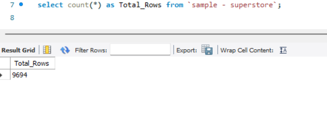

#### Insight:

#### The query verifies the total number of records available for analysis.

### a. Check Missing Sales Values

### select count(*) as missing_sales from `sample - superstore` where sales is null;

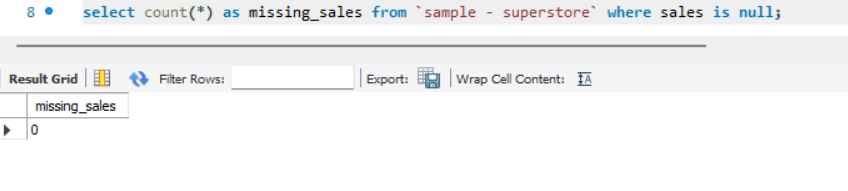

#### Insight:

#### The query checks for missing values in Sales to ensure data quality.

### b. Check Missing Customer Names

### select count(*) as missing_customers from `sample - superstore` where `Customer Name` is null;

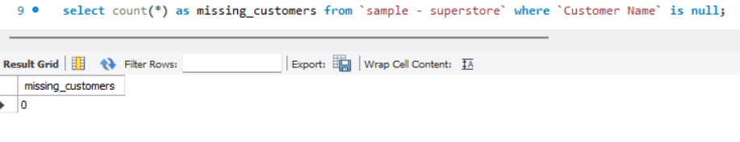

#### Insight:

#### The query checks for missing values in Customers to ensure data quality.

### c. Check Missing Product Names

### select count(*) as missing_products from `sample - superstore` where `Product Name` is null;

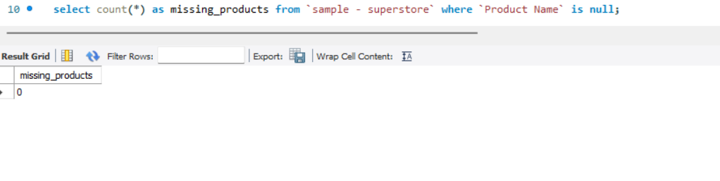

#### Insight:

#### The query checks for missing values in Products to ensure data quality.